# Analysis

```r
# Load packages
library(tidyverse)
```

```r
library(ggplot2)
library(readxl)
library(lubridate)
library(broom)
library(viridis)
library(tsModel)
library(scales)
library(grid)
library(tseries)
library(tsibble)
library(fable)
library(feasts)
library(forecast)

# Global options
knitr::opts_chunk$set(echo = TRUE, warning = FALSE, message = FALSE)
```

This contains all code used to analyze the datasets found in the `/CleanData` directory, which were previously generated in the `/Scripts/Cleaning.rmd` file.

#Introduction

There are several studies that use the interupted time series ARIMA, but we are primarily going to replicate the methods described in [Singh et al., 2025](https://link.springer.com/article/10.1007/s00127-025-02902-7), a study which analyzes suicide deaths among reproductive-aged women post-*Dobbs*.

This study also uses data from the Multiple Cause of Death database, and stratifies data by men and women by two age groups: 15-25 and 25-49. The outcomes are the monthly count of suicides nationally for reproductive-aged women overall and for the two age subgroups. The series of monthly suicides among men (per age group) were used as a control variable. The exposure was the timing of the *Dobbs* decision in June 2022.

To extend this methodology to our study, we can also use male deaths as a control. Since we are using just texas data, it is unlikely that we will have enough counts to populate data if we further stratify by age 15-24 and 25-49. However, we will also do a sensitivity analysis that compares our trends to those nationally.

*Note: the following description is directly adapted from Singh et al. (2025). Future methods manuscripting will need to cite this source as well as adapt the phrasing.*

The ARIMA’s autoregressive (AR) component should allow us to capture the relationship between current assault mortality counts and past observations. The moving average (MA) will model the residuals from previous time points (accounting for irregular fluctuations). The seasonality/trends that change over time will be addressed through differencing (“integrated”), which will remove secular trends and stabilize the mean.

We may use the methods from Singh et al. (2025) in the following steps:

1. Use the Box-Jenkins iterative pattern recognition routines to identify the ARIMA signature of the outcome in the pre-Bill 8 period (January, 2018 - August, 2021), controlling for the concomitant series of assault mortality among men of the same age group (15-44).
2. Use the pre-Bill 8 ARIMA signature identified in step 1 to forecast (predict) values of the outcome for the 28-month period post-Bill 8 (i.e. September 2021 - December 2023). These predicted/fitted values will serve as counterfactuals and reflect the expected monthly count of female suicides if Bill 8 had not been passed.
3. Use the ARIMA signature identified in step 1 and expected values from step 2 to obtain residual values (observed less fitted) of our outcome series.
4. Use the pre-Bill 8 standard error of residuals to develop pre-Bill 8 95% confidence intervals (CI; prediction interval of monthly series of assault mortalities among Texas resident reproductive-aged women overall from January 2018 - August 2021). Extend the pre-Bill 8 prediction interval to the full residual series (January 2018 - December 2023). Next, note whether any residuals deviated from this prediction interval post-Bill 8 (i.e., September 2021 onward.)
5. If the outcome series exhibited outliers in the post-Bill 8 period following step 4, create a binary indicator of the month-specified timing of any identified outliers in residuals of assault mortalities among reproductive-aged women post-Bill 8 (1 for months with outliers, 0 otherwise) to quantify the average change in assault mortalities post-Bill 8. This will also help avoid multiple testing that could increase chances of a Type I error (false rejection of the null).
6. Apply the binary-indicator of month-specific outliers (from step 5) to the ARIMA-derived residuals of outcomes to determine the magnitude of outcome deviation from expected levels in the months with residual outliers.

2-tailed tests with significance level of p < 0.05 will be used.

#Descriptive Statistics

We are going to start by exploring how many assault mortalities among Texas residents occured between the study period.

```r
monthly_f <- read.csv("../CleanData/monthly_f.csv")
monthly_m <- read.csv("../CleanData/monthly_m.csv")
monthly_all <- read.csv("../CleanData/monthly_all.csv")

monthly_f <- monthly_f %>%
  mutate(month_year = ymd(month_year))

monthly_m <- monthly_m %>%
  mutate(month_year = ymd(month_year))

monthly_all <- monthly_all %>%
  mutate(month_year = ymd(month_year))
```

```r
monthly_all %>%
  group_by(sex) %>%
  summarise(
    n_months      = n(),
    total_deaths  = sum(Deaths, na.rm = TRUE),
    monthly_mean  = mean(Deaths, na.rm = TRUE),
    monthly_sd    = sd(Deaths, na.rm = TRUE),
    .groups = "drop"
  )
```

```
## # A tibble: 2 × 5
##   sex    n_months total_deaths monthly_mean monthly_sd
##   <chr>     <int>        <int>        <dbl>      <dbl>
## 1 Female       72         1525         21.2       5.59
## 2 Male         72         7127         99.0      22.3
```

```r
monthly_all %>%
  filter(month_year == "2021-09-01") %>%
  pull(time)
```

```
## [1] 45 45
```

```r
monthly_all %>%
  filter(month_year == as.Date("2021-09-01")) %>%
  select(sex, month_year, time)
```

```
##      sex month_year time
## 1 Female 2021-09-01   45
## 2   Male 2021-09-01   45
```

# 1 Box-Jenkins routines

Next we will identify the ARIMA signature of the monthly series of assault deaths among reproductive-aged women, controlling for the concomitant series of male assault deaths.

[This is copying table 2 in the manuscript]

I am going to replicate the methodology from the [RPubs report on Box-Jenkins](https://rpubs.com/asmuierahim/boxjenkins).

First, we need to define the variable as a time series object using the ts() function. We need to specify the start =, end =, and frequency. I am going to start by just incorporating female data.

```r
monthly_f_ts <- ts(
  monthly_f$Deaths,
  start = c(2018, 1),
  frequency = 12
)
```

Next, we plot the original series.

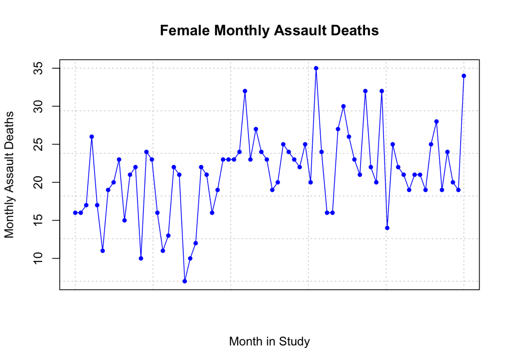

```r
plot(monthly_f_ts, col = "blue", ylab = "Monthly Assault Deaths",
      main = "Female Monthly Assault Deaths", xlab = "Month in Study", type ="o", pch = 20,
      panel.first = grid (),  xaxt = "n")
axis(1, at = seq (from = 1, to = 72, by = 2)) # additional graph customization
```

Next, we plot the Autocorrelation Function (ACF) and Partial Autocorrelation Function (PACF) for the original series.

The ACF shows the correlation between the current observation and its past observations at various lag points.

The PACF shows the correlation between the current observation and its past observations, removing the effects of intermediate observations. We will be using a lag max at 24 months to identify short-term dependence, a seasonal signal at lag 12, and whether effects persist past 1 year.

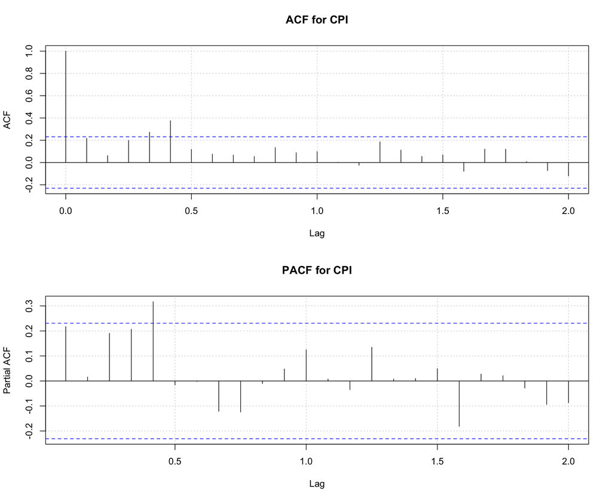

```r
par(mfrow = c(2,1)) #2 graphs in a single device
acf(monthly_f_ts,
    24,
    main = "ACF for CPI",
    panel.first = grid ())

pacf(monthly_f_ts,
     24,
     main = "PACF for CPI",
     panel.first = grid ())
```

# 2 Using Rpubs Tidy version

From this [RPubs article](https://rpubs.com/jcorbin/tidy_itt_arima)

Uploading data and converting to a tsibble object:

```r
monthly <- read.csv("../CleanData/monthly_f.csv")
monthly.ts <- monthly %>%
  select(-sex) %>%
  mutate(month_year = ymd(month_year),
         month = yearmonth(month_year)) %>%
  as_tsibble(index = month)

glimpse(monthly.ts)
```

```
## Rows: 72
## Columns: 5
## $ Deaths     <int> 16, 16, 17, 26, 17, 11, 19, 20, 23, 15, 21, 22, 10, 24, 23,…
## $ month_year <date> 2018-01-01, 2018-02-01, 2018-03-01, 2018-04-01, 2018-05-01…
## $ bill8      <lgl> FALSE, FALSE, FALSE, FALSE, FALSE, FALSE, FALSE, FALSE, FAL…
## $ time       <int> 1, 2, 3, 4, 5, 6, 7, 8, 9, 10, 11, 12, 13, 14, 15, 16, 17, …
## $ month      <mth> 2018 Jan, 2018 Feb, 2018 Mar, 2018 Apr, 2018 May, 2018 Jun,…
```

Looking at data, along with ACF and PACF plots:

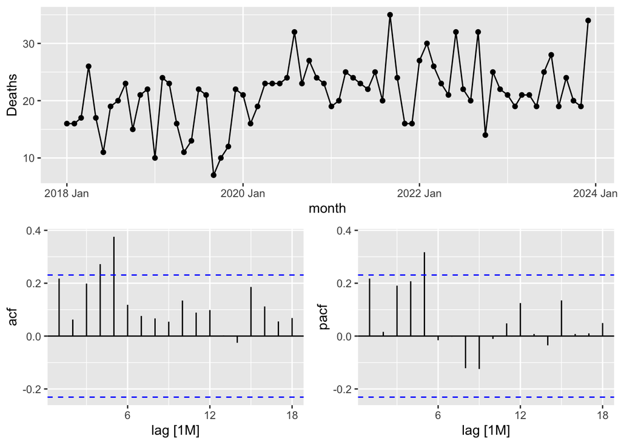

```r
monthly.ts |>
  gg_tsdisplay(y = Deaths, plot_type = "partial")
```

Looking at the PACF and ACF after differencing:

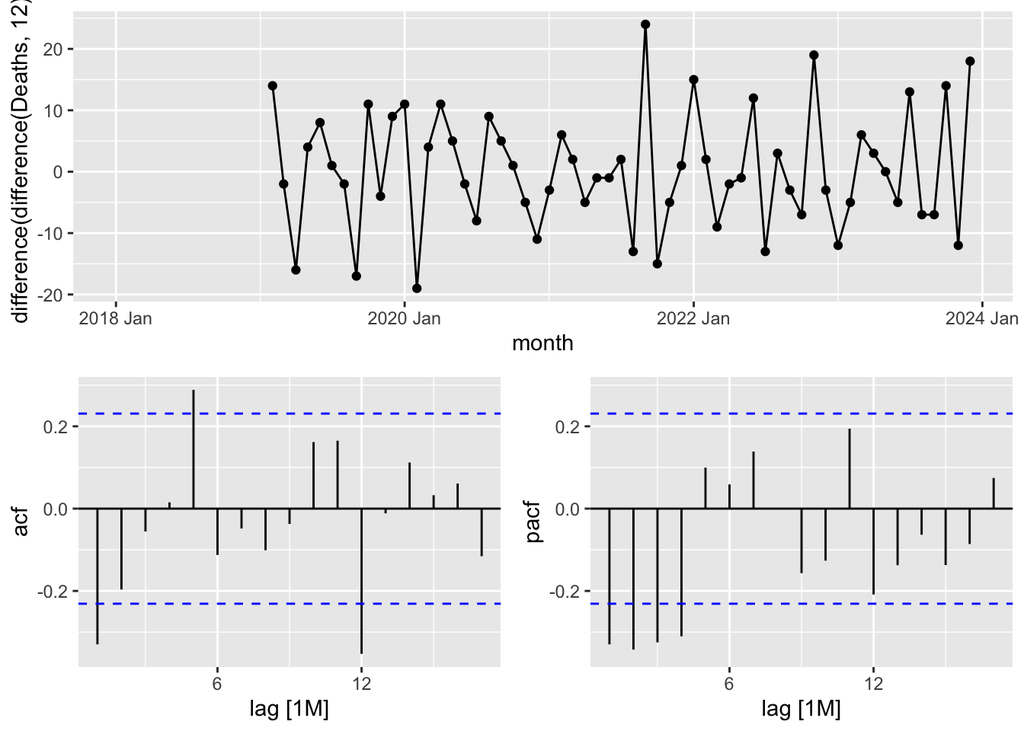

```r
monthly.ts |>
  gg_tsdisplay(y = difference(difference(Deaths,12)), plot_type = "partial")
```

Need to research when data is stationary vs. not…

Letting Fable’s ARIMA algorithm choose the best fit…

# 3 Intervention effects

we are capturing the intervention effects next - step and ramp variable. The first effect is captured by a step (or level shift) variable, which is a dummy variable that is 0 for all months prior to the intervention and 1 for intervention months. The second is a ramp variable, which is 0 for all months prior to the intervention and starts with 1 on the first month of the intervention and increases by 1 from there (e.g., Sep, 2021 = 1; Oct. = 2; etc…)

```r
range(monthly.ts$time)
```

```
## [1]  1 72
```

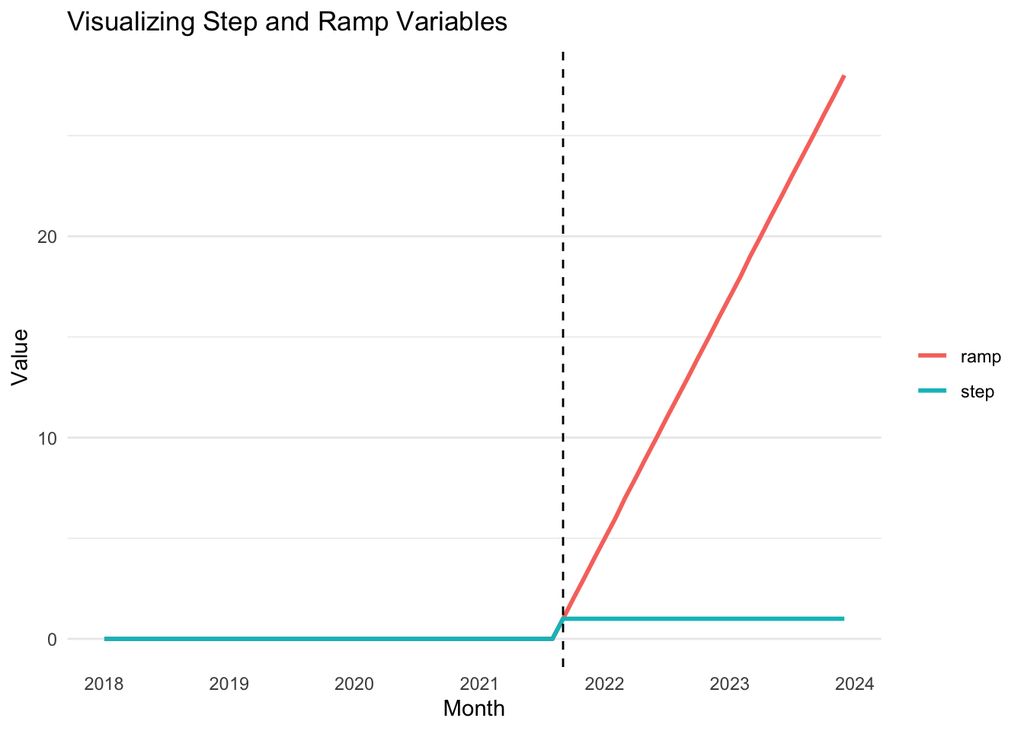

```r
# Create variable representing step and ramp changes
intervention_month <- monthly.ts %>%
  filter(month_year == "2021-09-01") %>%
  pull(time)
monthly.ts <- monthly.ts %>%
  mutate(
    t = row_number(),
    step = if_else(t >= intervention_month, 1, 0),
    ramp = if_else(t >= intervention_month, t - intervention_month + 1, 0)
  )

#View the step and ramp variables
monthly.ts %>%
  pivot_longer(
    cols = c(step, ramp),
    names_to = "variables",
    values_to = "value"
  ) %>%
  ggplot(aes(x = month_year, y = value, color = variables)) +
  geom_line(linewidth = 1) +
  geom_vline(
    xintercept = as.Date("2021-09-01"),
    linetype = "dashed",
    color = "black"
  ) +
  labs(
    title = "Visualizing Step and Ramp Variables",
    x = "Month",
    y = "Value",
    color = ""
  ) +
  scale_x_date(date_breaks = "1 year", date_labels = "%Y") +
  theme_minimal() +
  theme(
    panel.grid.major.x = element_blank(),
    panel.grid.minor.x = element_blank()
  )
```

# 4 ARIMA model

The Fable algorithm will dictate the model parameters. Next, we plot the residuals, the ACF plot, and a histogram to ensure they approximate a white noise series.

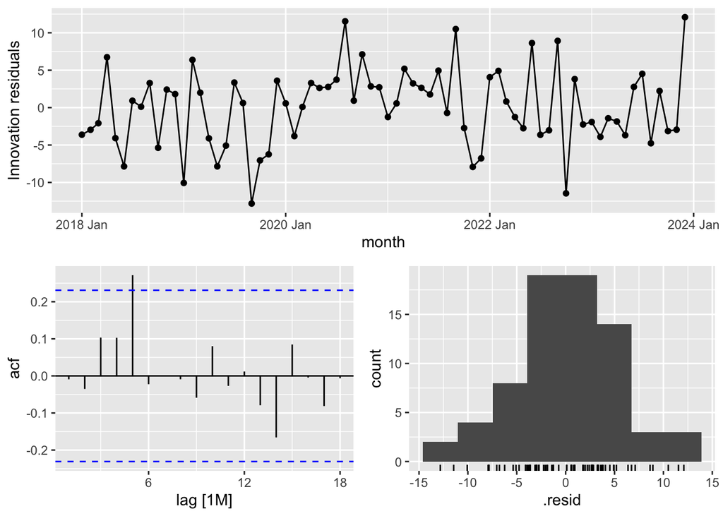

```r
# Use automated algorithm to identify p/q parameters
# Specify first difference = 1 and seasonal difference = 1
m_monthly.ts <- monthly.ts %>%
  model(arima = ARIMA(Deaths ~ step + ramp, stepwise = FALSE))

#Plotting model residuals
m_monthly.ts  %>%
  gg_tsresiduals()
```

Here we use the Ljung-Box test, which models if the residuals are still autocorrelated. Null: residuals are independent (white noise) Alternative: residuals show remaining autocorrelation

```r
#Ljung-Box test
augment(m_monthly.ts) %>%
  features(.resid, ljung_box)
```

```
## # A tibble: 1 × 3
##   .model lb_stat lb_pvalue
##   <chr>    <dbl>     <dbl>
## 1 arima  0.00630     0.937
```

We got a p-val of .94, meaning we fail to reject the null (there is no evidence of remaining autocorrelation, the ARIMA has adequately captured the time dependence in the data).

We also want to check again, making sure we are testing enough lags:

```r
augment(m_monthly.ts) %>%
  features(.resid, ljung_box, lag = 24)
```

```
## # A tibble: 1 × 3
##   .model lb_stat lb_pvalue
##   <chr>    <dbl>     <dbl>
## 1 arima     20.3     0.681
```

Our p-value is still large (0.68), meaning we can comfortably conclude that the model residuals show no evidence of autocorrelation.

With the model assumptions satisfied, we can take a look at the model estimates:

```r
report(m_monthly.ts)
```

```
## Series: Deaths
## Model: LM w/ ARIMA(0,0,1) errors
##
## Coefficients:
##          ma1    step     ramp  intercept
##       0.2059  5.0298  -0.0787    19.6940
## s.e.  0.1314  2.5554   0.1428     0.9364
##
## sigma^2 estimated as 28.22:  log likelihood=-220.36
## AIC=450.73   AICc=451.64   BIC=462.11
```

It picked up **p=0**, meaning there are no autoregressive terms (the current value is not directly predicted by past raw data values).

**d=0**, meaning there is no differencing; the original, raw data is stationary, possessing no trend.

**q=1**: there is one moving average term, aka the model uses the error from the previous tie step to predict the current value

The ARIMA estimated an immediate increase in **5 deaths** and an estimated reduction of **-0.07 deaths** each month after Bill 8 was enacted.

```r
#Modeling counterfactual
m_counterfactual <- monthly.ts %>%
  filter(month < make_yearmonth(2021, 9)) %>%
  model(
    arima_null = ARIMA(
      Deaths,
      stepwise = FALSE
    )
  )
report(m_counterfactual)
```

```
## Series: Deaths
## Model: ARIMA(4,1,0)
##
## Coefficients:
##           ar1      ar2      ar3      ar4
##       -0.6705  -0.7347  -0.5302  -0.2601
## s.e.   0.1486   0.1587   0.1580   0.1481
##
## sigma^2 estimated as 22.32:  log likelihood=-126.3
## AIC=262.6   AICc=264.22   BIC=271.41
```

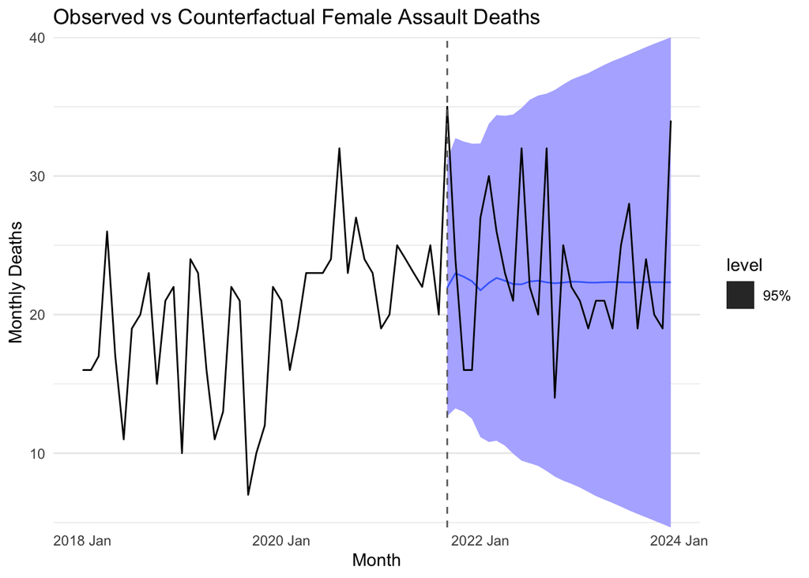

```r
#forecast into post-intervention period
fc_counterfactual <- m_counterfactual %>%
  forecast(h = 28)

 autoplot(fc_counterfactual, monthly.ts, level = 95) +
  geom_vline(
    xintercept = as.numeric(as_date(make_yearmonth(2021, 9))),
    linetype = "dashed",
    color = "grey40"
  ) +
  labs(
    title = "Observed vs Counterfactual Female Assault Deaths",
    y = "Monthly Deaths",
    x = "Month"
  ) +
  scale_y_continuous(expand = c(0, 0)) +
  theme_minimal() +
  theme(
    panel.grid.major.x = element_blank(),
    panel.grid.minor.x = element_blank()
  )
```

Another attempt, trying to directly replicate provided code and try other things (changing the seasonal components, period change, etc)

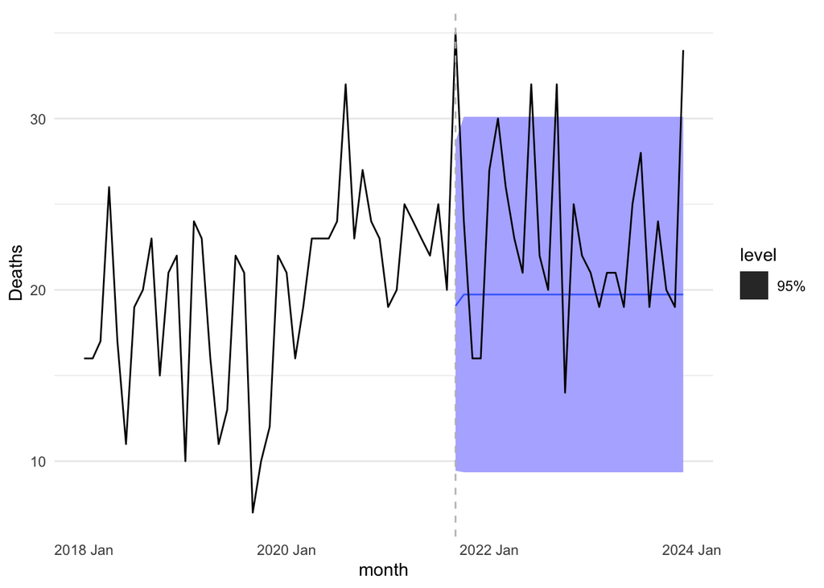

```r
#Modeling counterfactual
#LM w/ ARIMA(0,0,1) errors
m_counterfactual <- monthly.ts %>%
  filter(month < make_yearmonth(2021, 9)) %>%
  model(arima_null = ARIMA(Deaths ~ pdq(0,0,1) #Specifies non-seasonal components of the model
                           + PDQ(0,0,0, #specifies seasonal components of the model
                                 period = 12))) #period is number of observations in each seasonal period


fc_counterfactual <- m_counterfactual %>%
  forecast(h = 28)
#Forecasting counterfactual and plotting against actual data
m_counterfactual %>%
  forecast(h = 28)  %>%
  autoplot(monthly.ts, level = 95) +
  geom_vline(xintercept = as.numeric(as_date(make_yearmonth(2021, 9))),
             linetype = "dashed",
             color = "grey") +
  theme_minimal() +
  theme(panel.grid.major.x = element_blank(),
        panel.grid.minor.x = element_blank())
```

We are also going to try usting auto.arima() to see whether the model parameters differ. We are going to apply to autoarima to just the months prior to sept 2021, then try again with the entire series of data.

```r
library(forecast)
#just pre-bill 8
auto_monthly.ts <- monthly.ts %>%
  filter(month < make_yearmonth(2021, 9)) %>%
  select(Deaths) %>%
  auto.arima()

summary(auto_monthly.ts)
```

```
## Series: .
## ARIMA(0,1,1)
##
## Coefficients:
##           ma1
##       -0.7554
## s.e.   0.1138
##
## sigma^2 = 24.95:  log likelihood = -130.09
## AIC=264.19   AICc=264.49   BIC=267.71
##
## Training set error measures:
##                     ME     RMSE      MAE       MPE     MAPE      MASE
## Training set 0.5433699 4.880055 3.960129 -5.229736 24.45338 0.6034482
##                    ACF1
## Training set 0.08676675
```

```r
#all data points
auto_monthly.ts2 <- monthly.ts %>%
  select(Deaths) %>%
  auto.arima()

summary(auto_monthly.ts2)
```

```
## Series: .
## ARIMA(0,1,1)
##
## Coefficients:
##           ma1
##       -0.8571
## s.e.   0.0670
##
## sigma^2 = 28.34:  log likelihood = -219.63
## AIC=443.25   AICc=443.43   BIC=447.78
##
## Training set error measures:
##                     ME    RMSE      MAE       MPE     MAPE      MASE
## Training set 0.6194047 5.24906 4.246385 -4.185464 22.92439 0.6794216
##                     ACF1
## Training set 0.005925834
```

Both of these picked up ARIMA(0,1,1) instead of (0,0,1). Perhaps try to incorporate that into the non-seasonality??

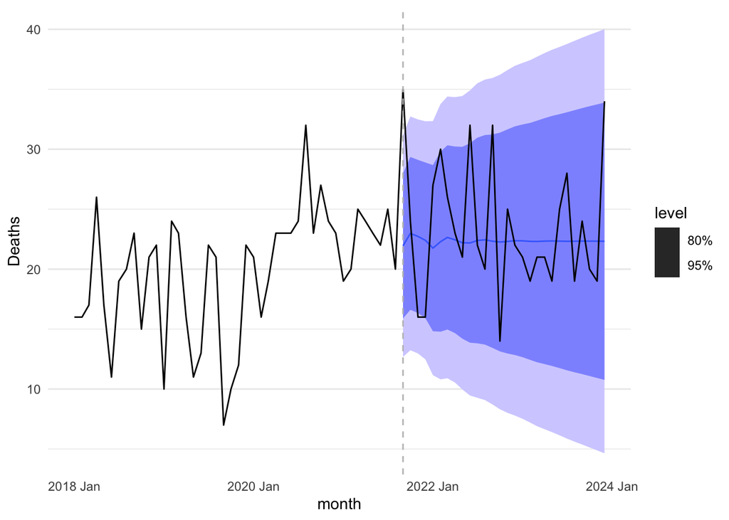

```r
m_counterfactual <- monthly.ts %>%
  filter(month <  make_yearmonth(2021, 9)) %>%
  model(
    arima_null = ARIMA(Deaths ~ pdq(4,1,0))
  )
#pre-specified

fc_counterfactual <- m_counterfactual %>%
  forecast(h = 28)
#Forecasting counterfactual and plotting against actual data
m_counterfactual %>%
  forecast(h = 28)  %>%
  autoplot(monthly.ts) +
  geom_vline(xintercept = as.numeric(as_date(make_yearmonth(2021, 9))),
             linetype = "dashed",
             color = "grey") +
  theme_minimal() +
  theme(panel.grid.major.x = element_blank(),
        panel.grid.minor.x = element_blank())
```

This looks pretty similar.

GO BACK IN AND READ PAPERS TO DOUBLE CHECK THIS IS DONE CORRECTLY

1. regress female deaths on male deaths
2. extract residuals (the controlled series, aka female deaths unexplained by male deaths)
3. acf/pacf of the residuals

code: 1. female_on_male <- lm(monthly_f_ts ~ monthly_m_ts) 2. female_resid_ts <- ts( residuals(female_on_male), start = c(2018, 1), frequency = 12 )

3. par(mfrow = c(2,1))

acf(female_resid_ts, lag.max = 24, main = “ACF of Female Deaths (Adjusted for Male Deaths)”, panel.first = grid())

pacf(female_resid_ts, lag.max = 24, main = “PACF of Female Deaths (Adjusted for Male Deaths)”, panel.first = grid())